# Primary school attendance rates of children by their disability status: Insights observed from data of Myanmar Census(2014)

UNICEF Myanmar, SPCRM 2023-06-07

# Overview

This analysis is based on the *township level* information data of Myanmar Census 2014.We are interested in examining the difference of school attendance rates between the children with *no disability* and their counterparts with *severe disability*.

Using the **REDATAM** that is designed to extract data from Census, we constructed two data sets at township level that are representing the primary school attendance rates of our groups of interest— normal vs. severe disability of the primary school age population of the 6-10 year old children.

State/Region aggregates are calculated.The results are visualized for comparing the situations of the groups.

All datasets produced in our analytical project can be found on the Github repository.We also provided a couple of R-script documents that we used during the process for data arrangement and analyses. *https://github.com/AungLwin25/Disability*

Particular credits to our colleagues, Bjorn Gelders for formulating the framework of analysis, and Aung Lwin for kniting algorithms, wrangling data, computing statistics, and producing visuals. — UNICEF Myanmar, SPCRM

# Average primary school attendances of townships

## Tables

### Summary statistics

```
##       SR                Normal          Severe
##  Length:15          Min.   :58.13   Min.   :20.98
##  Class :character   1st Qu.:80.53   1st Qu.:26.64
##  Mode  :character   Median :81.51   Median :31.29
##                     Mean   :80.18   Mean   :31.23
##                     3rd Qu.:83.97   3rd Qu.:35.02
##                     Max.   :87.20   Max.   :46.18
```

### State/region aggregates

```
## # A tibble: 15 × 3
##    SR          Normal Severe
##    <chr>        <dbl>  <dbl>
##  1 Ayeyawady     82.7   35.0
##  2 Bago          84.5   27.8
##  3 Chin          87.2   46.2
##  4 Kachin        81.5   31.5
##  5 Kayah         85.7   36.6
##  6 Kayin         71.7   32.2
##  7 Magway        84.7   31.3
##  8 Mandalay      82.0   25.6
##  9 Mon           81.2   27.7
## 10 Nay Pyi Taw   80.8   21.0
## 11 Rakhine       80.2   38.1
## 12 Sagaing       83.4   30.8
## 13 Shan          58.1   25.6
## 14 Tanintharyi   81.1   35.0
## 15 Yangon        77.9   24.0
```

## Visuals

### Boxplot

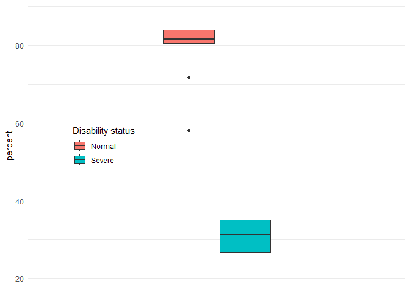

### Group bar

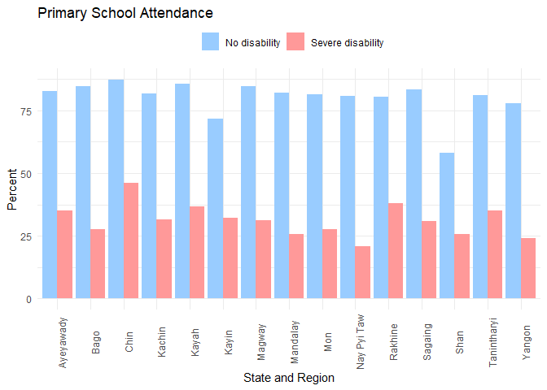

# Conclusion

The analytical results from Myanmar Census 2014 show that the children having *severe disability* were **hugely** lagging behind in their primary school attendance compared to those of the children with *no disability*.

# Appendix

## Data Table of township values

Primary School Attendance rates

| State/Region | Census Township | Male Severe | Female Severe | Total Severe | Male Normal | Female Normal | Total Normal |
| --- | --- | --- | --- | --- | --- | --- | --- |
| Kachin | Hsinbo(ST) | NA | NA | NA | 80.3 | 82.4 | 81.4 |
| Kachin | Myitkyina | 21.92 | 16.98 | 19.84 | 81.5 | 83.2 | 82.3 |
| Kachin | Hsadone(ST) | 33.33 | 50.00 | 40.00 | 82.9 | 83.1 | 83.0 |
| Kachin | Kanpaikti(ST) | NA | 50.00 | 20.00 | 78.5 | 80.0 | 79.3 |
| Kachin | Waingmaw | 36.36 | 55.88 | 44.87 | 87.6 | 88.3 | 88.0 |
| Kachin | Ingyanyan | NA | NA | NA | 64.5 | 72.3 | 68.3 |
| Kachin | Shinbwayyan(ST) | 50.00 | NA | 50.00 | 84.7 | 86.7 | 85.7 |
| Kachin | Tanaing | 36.36 | 23.08 | 29.17 | 75.0 | 78.1 | 76.5 |
| Kachin | Chiphwe | 33.33 | NA | 18.18 | 66.3 | 64.0 | 65.1 |
| Kachin | Panwa(ST) | NA | NA | NA | 50.6 | 45.6 | 48.0 |
| Kachin | Hsotlaw | 14.29 | NA | 14.29 | 70.4 | 67.3 | 68.9 |
| Kachin | Hopin(ST) | 9.09 | 83.33 | 35.29 | 87.4 | 90.5 | 88.9 |
| Kachin | Mohnyin | 21.74 | 20.00 | 20.83 | 90.3 | 91.4 | 90.8 |
| Kachin | Mogaung | 26.09 | 53.33 | 36.84 | 89.8 | 93.0 | 91.3 |
| Kachin | Phakant | 32.26 | 22.86 | 27.27 | 65.2 | 66.6 | 65.9 |
| Kachin | Kamine(ST) | NA | NA | NA | 78.4 | 79.6 | 79.0 |
| Kachin | Bhamo | 29.55 | 31.25 | 30.26 | 80.8 | 82.1 | 81.5 |
| Kachin | Myohla(ST) | NA | NA | NA | 90.1 | 92.5 | 91.2 |
| Kachin | Shwegu | 37.04 | 17.65 | 29.55 | 85.0 | 86.5 | 85.7 |
| Kachin | Lwe`ge`(ST) | NA | NA | NA | 57.5 | 59.1 | 58.3 |
| Kachin | Dotphoneyan(ST) | 40.00 | NA | 25.00 | 82.7 | 84.4 | 83.5 |
| Kachin | Momauk | 25.00 | NA | 11.77 | 91.7 | 93.7 | 92.7 |
| Kachin | Mansi | 52.63 | 18.75 | 37.14 | 82.5 | 82.3 | 82.4 |
| Kachin | Putao | 72.00 | 45.00 | 60.00 | 91.8 | 92.5 | 92.2 |
| Kachin | Sumprabum | NA | NA | NA | 93.5 | 91.2 | 92.4 |
| Kachin | Machanbaw | 28.57 | 33.33 | 30.00 | 92.5 | 93.6 | 93.0 |
| Kachin | Pannandin(ST) | NA | NA | NA | 81.4 | 76.1 | 78.7 |
| Kachin | Naungmoon | 50.00 | NA | 50.00 | 96.4 | 96.6 | 96.5 |
| Kachin | Khaunglanphoo | NA | NA | NA | 94.2 | 92.5 | 93.4 |
| Kayah | Loikaw | 34.29 | 52.00 | 41.67 | 87.2 | 89.3 | 88.2 |

[output cut: 385 more lines]